# Feature Importance Exploration - No IgM

# Load Data

This block performs the following operations:

1. Loads the raw data.
2. Selects the desired predictor variables.
3. Drops rows with missing data.
4. Prepares the target variable, transforming it from 4 classes to 2.

```r
set.seed(88)
data_csv <- here("data", "raw", "final_data.csv")
df <- read.csv(data_csv)

df <- df %>%
  select(-Sample) %>%
  drop_na() %>%
  mutate(Cohort = factor(if_else(Cohort %in% c("PP", "NP"), "Primary", "Latent")))
```

# Preprocessing

The following block uses the `recipes` library to log scale and normalize the predictors between 0 and 1.

```r
rec_obj <- recipe(Cohort ~ ., data = df)

normalizer <- rec_obj %>%
  step_log(all_predictors()) %>%
  step_range(all_predictors(), min = 0, max = 1)

trained_rec <- prep(normalizer, training = df)

norm_df <- bake(trained_rec, df)
```

# Predicting

The following block performs 10-fold cross validation using lasso regression with the `glmnet` package. `mod_df` removes all `IgM` features.

```r
# mod_df <- norm_df
mod_df <- norm_df[, -grep("^IgM", colnames(norm_df))]

perm_df <- mod_df %>%
  mutate(permCohort = sample(mod_df$Cohort), nrow(mod_df)) %>%
  select(-Cohort)
```

```r
myGrid = expand.grid(
  alpha = 1,
  lambda = seq(0.0001, 1, length = 100)
)

model <- train(
  Cohort ~ .,
  mod_df,
  method = 'glmnet',
  tuneGrid = myGrid,
  trControl = trainControl(
    method = "cv",
    number = 10,
    summaryFunction = twoClassSummary,
    classProbs = TRUE,
    verboseIter = TRUE
  )
)
model
```

```
## glmnet
##
## 101 samples
## 214 predictors
##   2 classes: 'Latent', 'Primary'
##
## No pre-processing
## Resampling: Cross-Validated (10 fold)
## Summary of sample sizes: 90, 91, 92, 91, 91, 91, ...
## Resampling results across tuning parameters:
##
##   lambda  ROC        Sens       Spec
##   0.0001  0.9626667  0.9300000  0.880
##   0.0102  0.9626667  0.9300000  0.880
##   0.0203  0.9626667  0.9466667  0.860
##   0.0304  0.9746667  0.9466667  0.860
##   0.0405  0.9786667  0.9466667  0.880
##   0.0506  0.9786667  0.9666667  0.880
##   0.0607  0.9826667  0.9666667  0.880
##   0.0708  0.9793333  0.9666667  0.855
##   0.0809  0.9833333  0.9500000  0.835
##   0.0910  0.9833333  0.9500000  0.835
##   0.1011  0.9833333  0.9500000  0.815
##   0.1112  0.9783333  0.9500000  0.815
##   0.1213  0.9783333  0.9500000  0.815
##   0.1314  0.9783333  0.9333333  0.815
##   0.1415  0.9743333  0.9333333  0.815
##   0.1516  0.9743333  0.9333333  0.815
##   0.1617  0.9743333  0.9333333  0.815
##   0.1718  0.9743333  0.9333333  0.795
##   0.1819  0.9743333  0.9333333  0.795
##   0.1920  0.9710000  0.9333333  0.795
##   0.2021  0.9743333  0.9333333  0.795
##   0.2122  0.9743333  0.9333333  0.795
##   0.2223  0.9743333  0.9333333  0.795
##   0.2324  0.9743333  0.9333333  0.795
##   0.2425  0.9670000  0.9333333  0.775
##   0.2526  0.9676667  0.9333333  0.755
##   0.2627  0.9693333  0.9333333  0.715
##   0.2728  0.9653333  0.9333333  0.715
```

[output cut: 61 more lines]

```
##   0.8990  0.5000000  1.0000000  0.000
##   0.9091  0.5000000  1.0000000  0.000
##   0.9192  0.5000000  1.0000000  0.000
##   0.9293  0.5000000  1.0000000  0.000
##   0.9394  0.5000000  1.0000000  0.000
##   0.9495  0.5000000  1.0000000  0.000
##   0.9596  0.5000000  1.0000000  0.000
##   0.9697  0.5000000  1.0000000  0.000
##   0.9798  0.5000000  1.0000000  0.000
##   0.9899  0.5000000  1.0000000  0.000
##   1.0000  0.5000000  1.0000000  0.000
##
## Tuning parameter 'alpha' was held constant at a value of 1
## ROC was used to select the optimal model using the largest value.
## The final values used for the model were alpha = 1 and lambda = 0.1011.
```

The following block repeats the operation in the previous block with permuted labels in order to simulate the null hypothesis.

```r
permModel <- train(
  permCohort ~ .,
  perm_df,
  method = 'glmnet',
  tuneGrid = myGrid,
  trControl = trainControl(
    method = "cv",
    number = 10,
    summaryFunction = twoClassSummary,
    classProbs = TRUE,
    verboseIter = TRUE
  )
)
permModel
```

```
## glmnet
##
## 101 samples
## 215 predictors
##   2 classes: 'Latent', 'Primary'
##
## No pre-processing
## Resampling: Cross-Validated (10 fold)
## Summary of sample sizes: 91, 91, 90, 91, 91, 90, ...
## Resampling results across tuning parameters:
##
##   lambda  ROC        Sens       Spec
##   0.0001  0.5341667  0.6066667  0.455
##   0.0102  0.5211667  0.5900000  0.455
##   0.0203  0.5386667  0.5800000  0.495
##   0.0304  0.5536667  0.5600000  0.465
##   0.0405  0.5268333  0.5800000  0.445
##   0.0506  0.5038333  0.5966667  0.400
##   0.0607  0.5168333  0.6500000  0.320
##   0.0708  0.5381667  0.6700000  0.320
##   0.0809  0.5535000  0.7100000  0.300
##   0.0910  0.5573333  0.8000000  0.250
##   0.1011  0.5243333  0.8766667  0.250
##   0.1112  0.5258333  0.8766667  0.090
##   0.1213  0.5200000  0.9333333  0.045
##   0.1314  0.5078333  0.9500000  0.000
##   0.1415  0.4598333  0.9666667  0.000
##   0.1516  0.4766667  0.9833333  0.000
##   0.1617  0.4766667  0.9833333  0.000
##   0.1718  0.4766667  0.9833333  0.000
##   0.1819  0.4766667  1.0000000  0.000
##   0.1920  0.5000000  1.0000000  0.000
##   0.2021  0.5000000  1.0000000  0.000
##   0.2122  0.5000000  1.0000000  0.000
##   0.2223  0.5000000  1.0000000  0.000
##   0.2324  0.5000000  1.0000000  0.000
##   0.2425  0.5000000  1.0000000  0.000
##   0.2526  0.5000000  1.0000000  0.000
##   0.2627  0.5000000  1.0000000  0.000
##   0.2728  0.5000000  1.0000000  0.000
```

[output cut: 61 more lines]

```
##   0.8990  0.5000000  1.0000000  0.000
##   0.9091  0.5000000  1.0000000  0.000
##   0.9192  0.5000000  1.0000000  0.000
##   0.9293  0.5000000  1.0000000  0.000
##   0.9394  0.5000000  1.0000000  0.000
##   0.9495  0.5000000  1.0000000  0.000
##   0.9596  0.5000000  1.0000000  0.000
##   0.9697  0.5000000  1.0000000  0.000
##   0.9798  0.5000000  1.0000000  0.000
##   0.9899  0.5000000  1.0000000  0.000
##   1.0000  0.5000000  1.0000000  0.000
##
## Tuning parameter 'alpha' was held constant at a value of 1
## ROC was used to select the optimal model using the largest value.
## The final values used for the model were alpha = 1 and lambda = 0.091.
```

The following block plots the ROC-AUC metric distributions for the real and permuted versions of the `glmnet` model as violin plots.

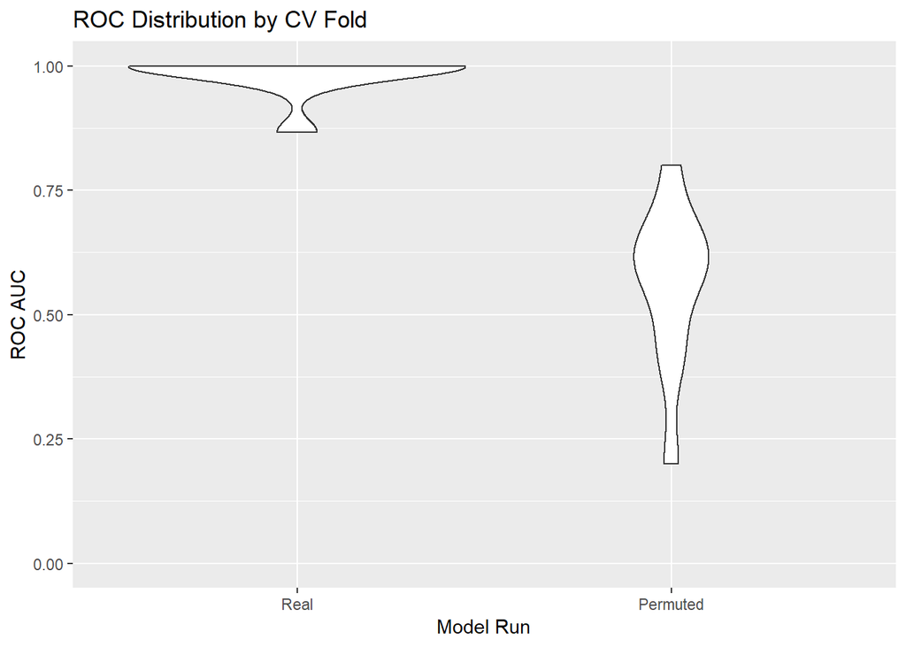

```r
realSamps <- model$resample %>%
  mutate(model = "Real")

permSamps <- permModel$resample %>%
  mutate(model = "Permuted")

box_df <- bind_rows(realSamps, permSamps)

ggplot(box_df, aes(fct_relevel(model, c("Real", "Permuted")), ROC)) +
  geom_violin() +
  expand_limits(y = 0) +
  labs(title = "ROC Distribution by CV Fold",
       x = "Model Run",
       y = "ROC AUC")
```

The following block plots the coefficients from the best model identified by `glmnet`.

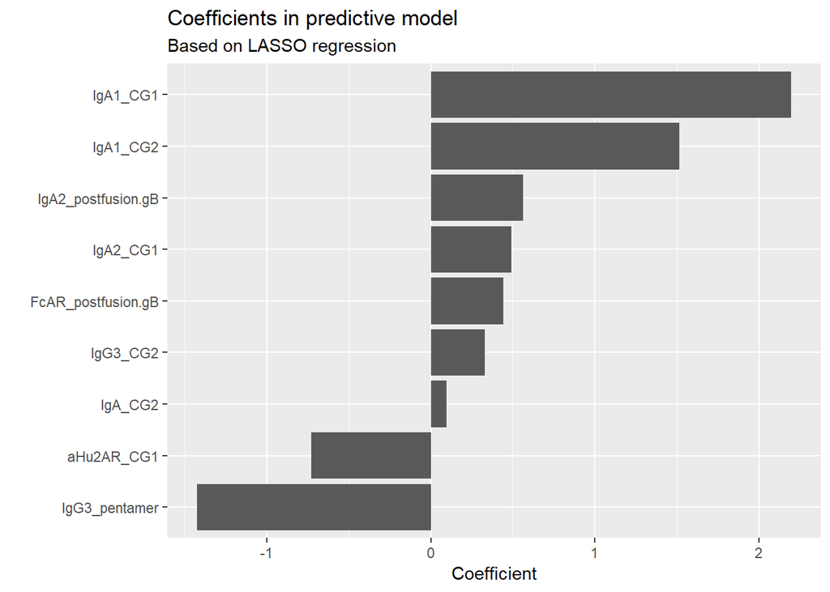

```r
# Predictor
feature_matrix <- mod_df %>%
  select(-Cohort) %>%
  as.matrix()

# Target
cohort <- mod_df$Cohort

lasso_fit <- glmnet(feature_matrix, cohort, family = "binomial", alpha = 1, lambda = model$bestTune$lambda)

lasso_fit %>%
  tidy() %>%
  arrange(desc(estimate)) %>%
  filter(term != "(Intercept)") %>%
  mutate(term = fct_reorder(term, estimate)) %>%
  ggplot(aes(term, estimate)) +
  geom_col() +
  coord_flip() +
  labs(title = "Coefficients in predictive model",
       subtitle = "Based on LASSO regression",
       x = "",
       y = "Coefficient")
```

# Evaluating

This block evaluates the performance of the model using the ROC metric.

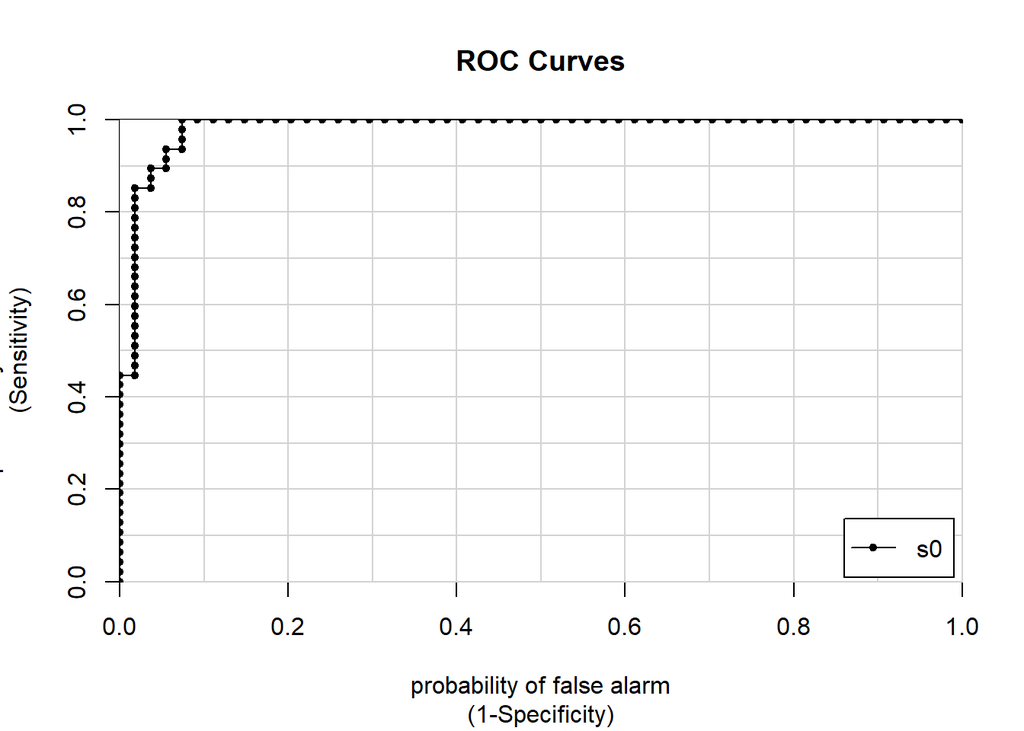

```
##                           s0
## Latent vs. Primary 0.9838455
```

```r
library(caTools)
preds <- predict(lasso_fit, feature_matrix, type = "response")

colAUC(preds, cohort, plotROC = TRUE)
```

This block trains an XGBoost model in order to investigate feature importance.

```r
labels = ifelse(mod_df$Cohort == "Primary", 1, 0)

dtrain <- mod_df %>%
  select(-Cohort) %>%
  as.matrix() %>%
  xgb.DMatrix(label = labels)

xgb_params <- list(
  booster = "gbtree",
  objective = "binary:logistic"
)

model_xgb <- xgb.train(
  params = xgb_params,
  data = dtrain,
  print_every_n = 5,
  nrounds = 60,
  verbose = 1
)
```

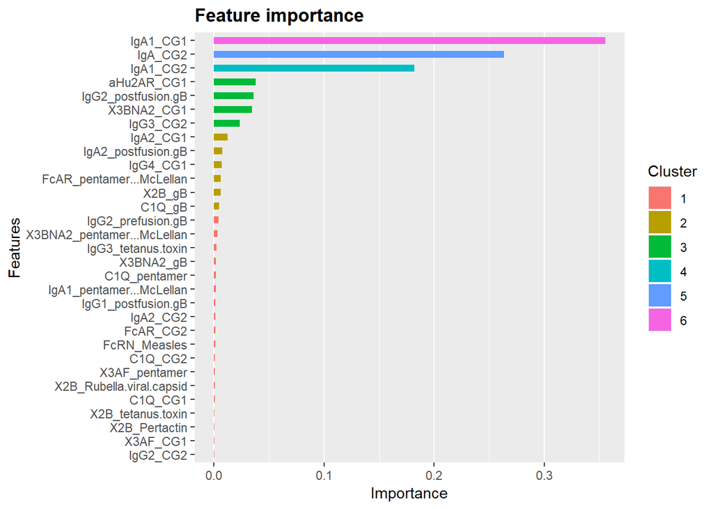

```r
importance_matrix <- xgb.importance(model = model_xgb)
xgb.ggplot.importance(importance_matrix)
```

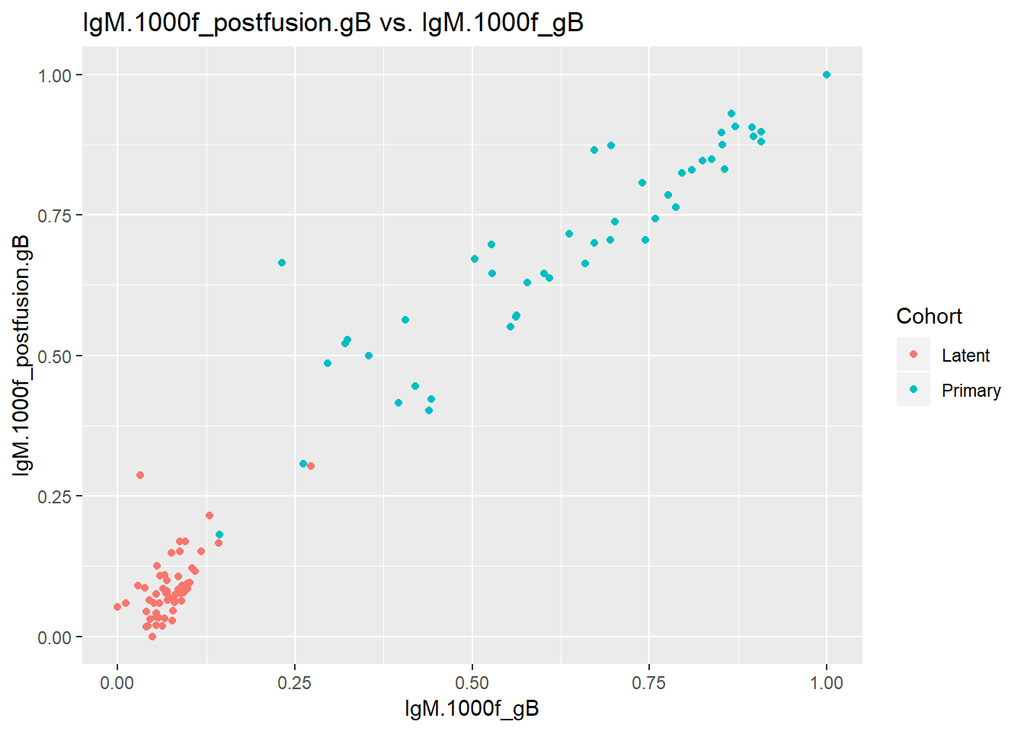

```r
ggplot(norm_df, aes(x = IgM.1000f_gB, y = IgM.1000f_postfusion.gB, color = Cohort)) +
  geom_point() +
  labs(title = "IgM.1000f_postfusion.gB vs. IgM.1000f_gB")
```

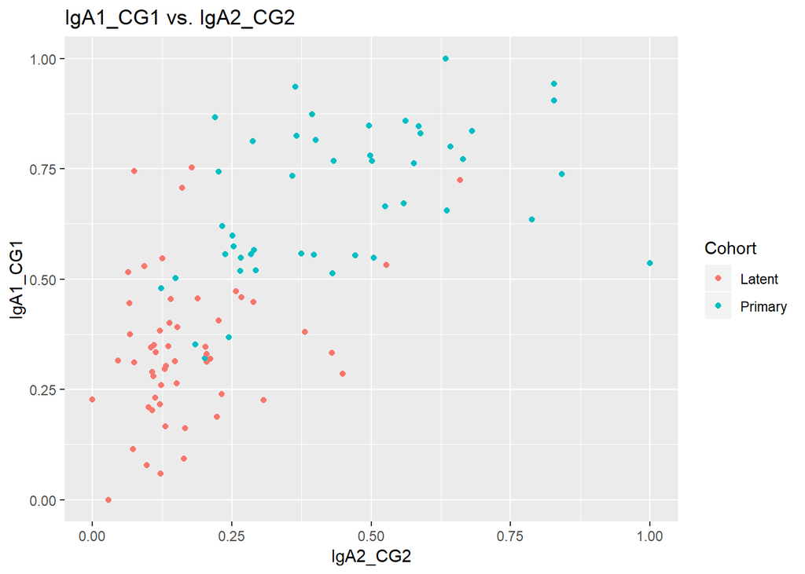

```r
ggplot(norm_df, aes(x = IgA2_CG2, y = IgA1_CG1, color = Cohort)) +
  geom_point() +
  labs(title = "IgA1_CG1 vs. IgA2_CG2")
```

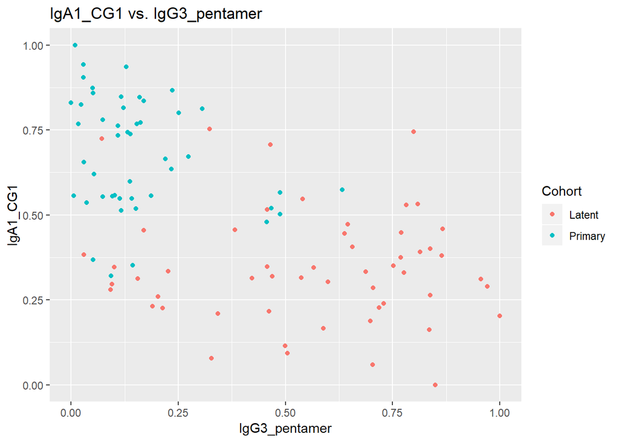

```r
ggplot(norm_df, aes(x = IgG3_pentamer, y = IgA1_CG1, color = Cohort)) +
  geom_point() +
  labs(title = "IgA1_CG1 vs. IgG3_pentamer")
```